# IE 423 Project Part 2

Gulce Yavuz Sercan Demirkılıc Baturalp Yalcın Utku Atay

02 Aralık 2019

# Project 2

## Part 1

### 1) Reading the image

After making it in greyscale, We had the photo in Jpeg Format and got it with “readJPEG” command.The size of the array is 400 x 400 x 3 for the three dimensions.

```r
library(jpeg)
photo <- readJPEG("C:/Users/Hasancan/Desktop/photo.jpg", native = FALSE)
```

### 2) Finding Row Outliers

Initially, we got the first layer of photo to use it. Then, we calculated the mean and standard deviation of each row in order to find the upper and lower bounds. Afterwards, we checked the each pixel whether in the bounds or not. If they are out of bounds, we set their pixel value to 0 which changes their colour black.

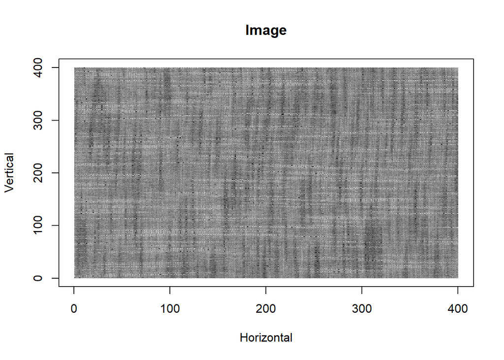

```r
pic_part1 = photo[, ,1]

significance_level=0.001
for(i in 1:400){
  for(j in 1:400){
    row= pic_part1[i, 1:400]
    dist_mean = mean(row) #calculate mean of the each row
    dist_sd = sd(row) #calculate standard deviation of the each row
    upper_bound = dist_mean + qnorm((1-significance_level/2))*dist_sd #calculate upperbound for each row
    lower_bound = dist_mean + qnorm(significance_level/2)*dist_sd #calculate lowerbound for each row
    if(pic_part1[i,j]>upper_bound | pic_part1[i,j]< lower_bound){
      pic_part1[i,j]=0 #out of control pixels converted to black pixel
    }}}

#print image
plot(0.5:400.5,0.5:400.5,type="n", xlab = "Horizontal", ylab = "Vertical", main = "Image")
rasterImage(pic_part1, 0.5,0.5, 400.5, 400.5,interpolate=FALSE)
```

### 3) Finding Column Outliers

In this part, we appltied same process as before. We calculated the mean and standard deviation of each column in order to find the upper and lower bounds. Afterwards, we checked the each pixel whether in the bounds or not. If they are out of bounds, we set their pixel value to 0 which changes their colour black.

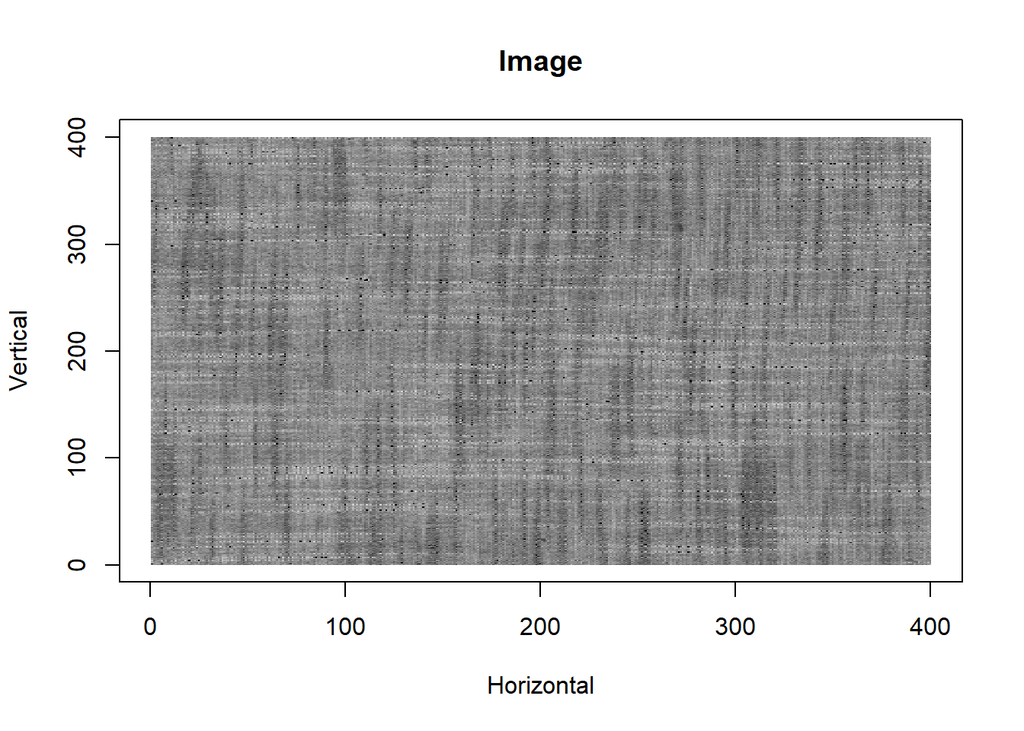

```r
for(i in 1:400){
  for(j in 1:400){
    column= pic_part1[1:400, i]
    dist_mean = mean(column) #calculate mean of the each column
    dist_sd = sd(column) #calculate standard deviation of the each column
    upper_bound = dist_mean + qnorm((1-significance_level/2))*dist_sd #calculate upperbound for each column
    lower_bound = dist_mean + qnorm(significance_level/2)*dist_sd #calculate lowerbound for each column
    if(pic_part1[j,i]>upper_bound | pic_part1[j,i]< lower_bound){
      pic_part1[j,i]=0 #out of control pixels converted to black pixel
    }}}

#print image
plot(0.5:400.5,0.5:400.5,type="n", xlab = "Horizontal", ylab = "Vertical", main = "Image")
rasterImage(pic_part1, 0.5,0.5, 400.5, 400.5,interpolate=FALSE)
```

## Part 2

### 1) Building a Regression Model

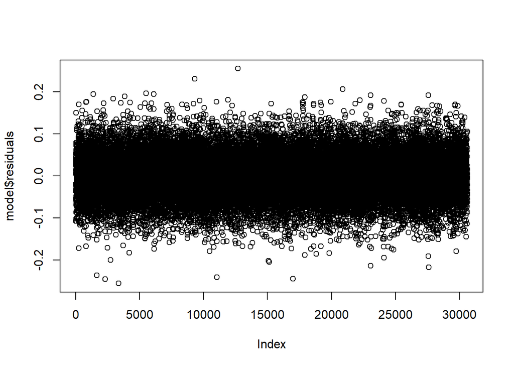

```r
pic_part2 = photo[, ,1]

patch_size=51
count=0
n_patchessmall = 175 #Taking the window difference as 2



#empty matrix for dependent and independent variables
variablessmall = matrix(data = NA, nrow = n_patchessmall*n_patchessmall, ncol = 2601)


#take a patch with size 51*51 for small number of patches
for(i in 1:n_patchessmall){
  for(j in 1:n_patchessmall){

    patch = pic_part2[(2*i-1):(2*i+patch_size-2),(2*j-1):(2*j+patch_size-2)]
    patchrow=as.matrix(t(patch))
    count = count + 1

    variablessmall[count, ] = patchrow #the other pixels are put into the other 2600 columns

  }
}

datasmall=data.frame(variablessmall)
model=lm(X1301~.,datasmall)
rm(variablessmall)


plot(model$residuals)
```

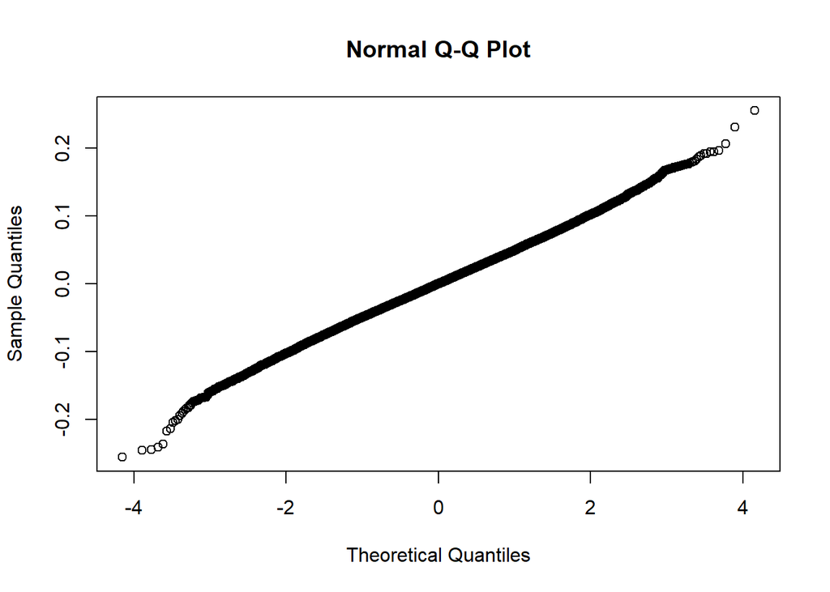

```r
qqnorm(model$residuals) # show that model is normal
```

### 2) Collecting all patches

To get whole residual values, we need to have all patches in the photo. Therefore, we get them by storing values in an empty matrix.

```r
count=0
n_patches = length(pic_part2[,1])-patch_size+1
variables = matrix(data = NA, nrow = n_patches*n_patches, ncol = 2601)


for(i in 1:n_patches){
  for(j in 1:n_patches){
    #take a patch with size 51*51
    patch = pic_part2[i:(i+patch_size-1),j:(j+patch_size-1)]
    patchrow=as.matrix(t(patch))
    count = count + 1

    variables[count,  ] = patchrow #the other pixels are put into the other 2600 columns

  }
}
data=data.frame(variables)
rm(variables)
```

### 3) Predicting the pixel estimations and calculating residuals

We predict the 1301th values by using our regression model. Then, we calculate residuals for each pixel and plot them.

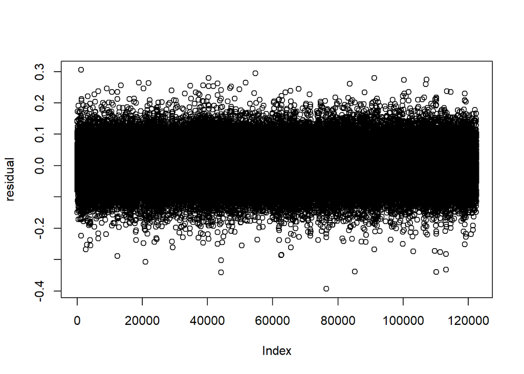

```r
prediction1=predict(model,newdata=data[1:30000,])
prediction2=predict(model,newdata=data[30001:60000,])
prediction3=predict(model,newdata=data[60001:90000,])
prediction4=predict(model,newdata=data[90001:122500,])
prediction=c(prediction1,prediction2,prediction3,prediction4)
residual=prediction-data$X1301

plot(residual)
```

### 4) Extracting residual outliers

Finally, we found the lower and upper bound of residuals by calculating mean and standart deviation values and make the pixel values of outliers to 0.

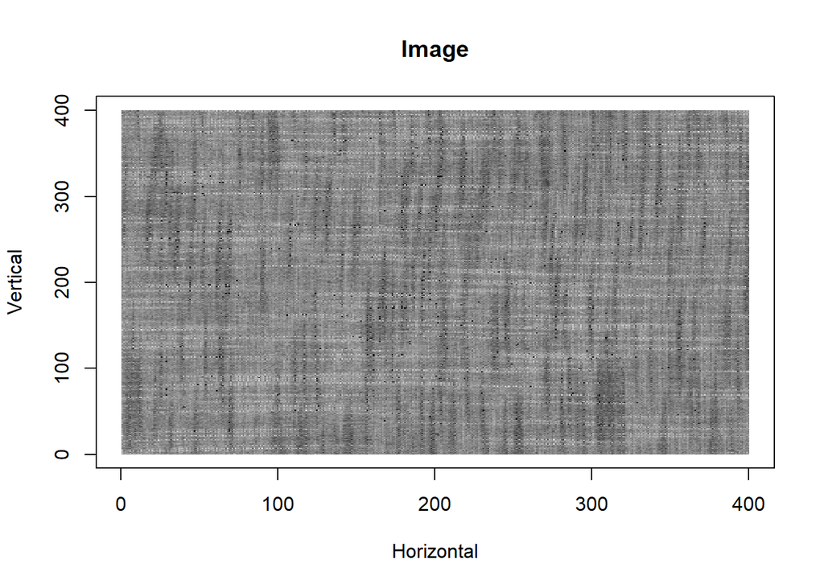

```r
significance_level=0.001

dist_mean = mean(model$residual)
dist_sd = sd(model$residual)
upper_bound = dist_mean + qnorm((1-significance_level/2))*dist_sd
lower_bound = dist_mean + qnorm(significance_level/2)*dist_sd

for(i in 1:350){
  for(j in 1:350){
    if(residual[(i-1)*350+j]>upper_bound | residual[(i-1)*350+j]< lower_bound){
      pic_part2[i+25,j+25]=0
    }}}

plot(0.5:400.5,0.5:400.5,type="n", xlab = "Horizontal", ylab = "Vertical", main = "Image")
rasterImage(pic_part2, 0.5,0.5, 400.5, 400.5,interpolate=FALSE)
```